# DB Call A Bike Rentals

Applied Statistics Course Project - Classification

Victor Bucholtz

# 1 Setup

Load packages

```r
# Load packages
library(tidymodels)
library(tidyverse)
library(ranger)
library(ggpubr)
```

Load data file

```r
# Import the RData file which contains the df_tageswerte data set
load(file = "bike_dwd.RData")

# Import data sets for public and school holidays
df_feiertage <- read_csv("Feiertage_Hamburg.csv")
df_schulferien <- read_csv("Schulferien_Hamburg.csv")
```

The data set is filtered for “Hamburg” and stored in a data frame. Afterwards we have a look at the data with glimpse().

```r
df_data <- df_tageswerte %>%
  filter(CITY_RENTAL_ZONE == "Hamburg")

glimpse(df_data)
```

```
## Rows: 1,232
## Columns: 21
## $ dateday          <date> 2014-01-01, 2014-01-02, 2014-01-03, 2014-01-04, 201…
## $ CITY_RENTAL_ZONE <fct> Hamburg, Hamburg, Hamburg, Hamburg, Hamburg, Hamburg…
## $ rentals          <dbl> 2519, 2984, 3466, 3793, 3021, 3507, 5312, 4448, 3957…
## $ dauer            <drtn> 21.95276 mins, 19.81032 mins, 19.12550 mins, 29.033…
## $ wochentag        <fct> Mittwoch, Donnerstag, Freitag, Samstag, Sonntag, Mon…
## $ QN_3             <dbl> 10, 10, 10, 10, 10, 10, 10, 10, 10, 10, 10, 10, 10, …
## $ FX               <dbl> 99, 132, 247, 118, 111, 151, 158, 127, 192, 159, 156…
## $ FM               <dbl> 5.1, 6.0, 5.6, 5.7, 3.9, 6.2, 6.9, 6.0, 7.2, 6.4, 6.…
## $ QN_4             <dbl> 3, 3, 3, 3, 3, 3, 3, 3, 3, 3, 3, 3, 3, 3, 3, 3, 3, 3…
## $ Niederschlag     <dbl> 0.9, 1.4, 2.4, 0.0, 0.9, 7.1, 0.0, 4.1, 4.6, 1.2, 5.…
## $ RSKF             <dbl> 6, 6, 6, 0, 6, 6, 6, 6, 6, 6, 8, 6, 6, 6, 6, 6, 6, 0…
## $ SDK              <dbl> 2.817, 0.167, 0.217, 3.333, 0.967, 0.000, 1.200, 0.2…
## $ SHK_TAG          <dbl> 0, 0, 0, 0, 0, 0, 0, 0, 0, 0, 0, 0, 0, 0, 0, 0, 0, 0…
## $ NM               <dbl> 4.9, 7.0, 4.8, 4.5, 4.5, 6.5, 6.0, 6.6, 7.4, 6.9, 6.…
## $ VPM              <dbl> 66, 83, 87, 75, 76, 89, 98, 95, 94, 82, 79, 70, 73, …
## $ PM               <dbl> 100712, 99933, 100180, 100215, 100172, 100294, 10066…
## $ TMK              <dbl> 3.5, 6.0, 6.7, 6.0, 4.6, 6.7, 10.1, 8.7, 8.3, 6.2, 5…
## $ UPM              <dbl> 8429, 8833, 8792, 8038, 8904, 8904, 7950, 8458, 8558…
## $ Temperatur       <dbl> 6.7, 9.1, 9.7, 7.7, 7.2, 10.6, 11.5, 9.5, 11.9, 7.2,…
## $ TNK              <dbl> 1.3, 2.6, 3.5, 4.8, 1.9, 1.7, 7.6, 6.3, 5.9, 5.4, 2.…
## $ TGK              <dbl> 0.1, 2.3, 2.3, 2.7, -0.5, 0.1, 5.1, 4.6, 3.9, 4.1, 1…
```

```r
glimpse(df_feiertage)
```

```
## Rows: 32
## Columns: 1
## $ Feiertage <chr> "01.01.14", "18.04.14", "01.05.17", "29.05.14", "30.05.14",…
```

```r
glimpse(df_schulferien)
```

```
## Rows: 269
## Columns: 1
## $ Ferien <chr> "31.01.14", "30.01.15", "29.01.16", "30.01.17", "03.03.14", "0…
```

## 1.1 Create features

We create different categorical features and change data types to investigate classification models / possibilities.

```r
# Ferien + Feiertag as.Date
df_schulferien$Ferien <- as.Date(df_schulferien$Ferien, tryFormats = c("%d.%m.%y"))
df_feiertage$Feiertage <- as.Date(df_feiertage$Feiertage, tryFormats = c("%d.%m.%y"))

# Create the categorical values "Wochenende", "warme_Tage", "Regen", "Feiertag", "Schulferien", "lange_Fahrt" und "freier Tag".
df_data <- df_data %>%
  mutate(Wochenende = ifelse(wochentag == 'Samstag' | wochentag == 'Sonntag', 1, 0)) %>%
  mutate(warme_Tage = ifelse(Temperatur > median(Temperatur), 1, 0)) %>%
  mutate(Regen = ifelse(Niederschlag > 0, 1, 0))  %>%
  mutate(Feiertag = ifelse(df_data$dateday %in% df_feiertage$Feiertage, 1, 0)) %>%
  mutate(Schulferien = ifelse(df_data$dateday %in% df_schulferien$Ferien, 1, 0)) %>%
  mutate(lange_Fahrt = ifelse(dauer > median(dauer), 1, 0)) %>%
  mutate(freierTag = ifelse(Feiertag > 0 | Wochenende > 0, "frei", "nichtFrei"))

# Data type conversions of "freierTag" and "dauer"
df_data$freierTag <- as.factor(df_data$freierTag)
df_data$dauer = as.double.difftime(df_data$dauer)

glimpse(df_data)
```

```
## Rows: 1,232
## Columns: 28
## $ dateday          <date> 2014-01-01, 2014-01-02, 2014-01-03, 2014-01-04, 201…
## $ CITY_RENTAL_ZONE <fct> Hamburg, Hamburg, Hamburg, Hamburg, Hamburg, Hamburg…
## $ rentals          <dbl> 2519, 2984, 3466, 3793, 3021, 3507, 5312, 4448, 3957…
## $ dauer            <dbl> 21.95276, 19.81032, 19.12550, 29.03322, 23.54783, 14…
## $ wochentag        <fct> Mittwoch, Donnerstag, Freitag, Samstag, Sonntag, Mon…
## $ QN_3             <dbl> 10, 10, 10, 10, 10, 10, 10, 10, 10, 10, 10, 10, 10, …
## $ FX               <dbl> 99, 132, 247, 118, 111, 151, 158, 127, 192, 159, 156…
## $ FM               <dbl> 5.1, 6.0, 5.6, 5.7, 3.9, 6.2, 6.9, 6.0, 7.2, 6.4, 6.…
## $ QN_4             <dbl> 3, 3, 3, 3, 3, 3, 3, 3, 3, 3, 3, 3, 3, 3, 3, 3, 3, 3…
## $ Niederschlag     <dbl> 0.9, 1.4, 2.4, 0.0, 0.9, 7.1, 0.0, 4.1, 4.6, 1.2, 5.…
## $ RSKF             <dbl> 6, 6, 6, 0, 6, 6, 6, 6, 6, 6, 8, 6, 6, 6, 6, 6, 6, 0…
## $ SDK              <dbl> 2.817, 0.167, 0.217, 3.333, 0.967, 0.000, 1.200, 0.2…
## $ SHK_TAG          <dbl> 0, 0, 0, 0, 0, 0, 0, 0, 0, 0, 0, 0, 0, 0, 0, 0, 0, 0…
## $ NM               <dbl> 4.9, 7.0, 4.8, 4.5, 4.5, 6.5, 6.0, 6.6, 7.4, 6.9, 6.…
## $ VPM              <dbl> 66, 83, 87, 75, 76, 89, 98, 95, 94, 82, 79, 70, 73, …
## $ PM               <dbl> 100712, 99933, 100180, 100215, 100172, 100294, 10066…
## $ TMK              <dbl> 3.5, 6.0, 6.7, 6.0, 4.6, 6.7, 10.1, 8.7, 8.3, 6.2, 5…
## $ UPM              <dbl> 8429, 8833, 8792, 8038, 8904, 8904, 7950, 8458, 8558…
## $ Temperatur       <dbl> 6.7, 9.1, 9.7, 7.7, 7.2, 10.6, 11.5, 9.5, 11.9, 7.2,…
## $ TNK              <dbl> 1.3, 2.6, 3.5, 4.8, 1.9, 1.7, 7.6, 6.3, 5.9, 5.4, 2.…
## $ TGK              <dbl> 0.1, 2.3, 2.3, 2.7, -0.5, 0.1, 5.1, 4.6, 3.9, 4.1, 1…
## $ Wochenende       <dbl> 0, 0, 0, 1, 1, 0, 0, 0, 0, 0, 1, 1, 0, 0, 0, 0, 0, 1…
## $ warme_Tage       <dbl> 0, 0, 0, 0, 0, 0, 0, 0, 0, 0, 0, 0, 0, 0, 0, 0, 0, 0…
## $ Regen            <dbl> 1, 1, 1, 0, 1, 1, 0, 1, 1, 1, 1, 0, 1, 0, 1, 1, 1, 0…
## $ Feiertag         <dbl> 1, 0, 0, 0, 0, 0, 0, 0, 0, 0, 0, 0, 0, 0, 0, 0, 0, 0…
## $ Schulferien      <dbl> 0, 1, 1, 0, 0, 0, 0, 0, 0, 0, 0, 0, 0, 0, 0, 0, 0, 0…
## $ lange_Fahrt      <dbl> 1, 0, 0, 1, 1, 0, 0, 0, 0, 1, 0, 0, 0, 0, 0, 0, 0, 1…
## $ freierTag        <fct> frei, nichtFrei, nichtFrei, frei, frei, nichtFrei, n…
```

# 2 Business Understanding

We want to train a classification model that can predict whether the day of rental is a day off (weekend or holiday) based on our data.

Possible use cases could be maintenance planning or a determination of the minimum availability of bicycles on free or non-free days.

We measure our model performance using the key figure of the harmonic mean “F1” as in this fictitious example we prefer to choose the model which performs overall well.

# 3 Data Splitting

Create training and test data:

```r
set.seed(123)

# Split into training and test set
split_data <- initial_split(df_data, strata = freierTag)
train_data <- training(split_data)
test_data <- testing(split_data)
```

# 4 Recipe and functions

## 4.1 Recipe

We create a recipe “class_rec” for our data preprocessing.

```r
# Recipe definition
class_rec <-
  recipe(freierTag ~ ., # response variable
         data = train_data) %>%
  step_rm(dateday, wochentag, Wochenende, Feiertag, FM) %>% # exclude variables which correlate with our response
  step_dummy(all_nominal(), -all_outcomes()) %>%  # create dummies for categorial variables
  step_zv(all_predictors()) %>% # remove variables that contain only a single value
  step_corr(all_predictors()) # remove variables that have large absolute correlations with other variables
```

## 4.2 Functions

Define functions for Recall, Precision and F1

```r
# Recall
func_recall <- function(TP, FN) {
  (TP / ( TP + FN))
}

# Precision
func_precision <- function(TP, FP) {
  (TP / (TP + FP))
}

# F1
func_f_meas <- function(precision, recall) {
  2 * precision * recall / (precision + recall)
}
```

# 5 Data Exploration & statistics

In this step, we take a look at the distribution of our rentals on free/non-free days.

```r
table(train_data$freierTag)
```

```
##
##      frei nichtFrei
##       283       642
```

```r
283 / (283 + 642) # percentage of free days
```

```
## [1] 0.3059459
```

30.6% of our days are free days.

```r
train_data %>%
  group_by(freierTag) %>%
  dplyr::summarize(rentals=sum(rentals))
```

| freierTag | rentals |
| --- | --- |
| frei | 1867011 |
| nichtFrei | 4853468 |

```r
1867011 / (1867011+4853468) # percentage of rentals on free days
```

```
## [1] 0.2778092
```

27.8% of our rentals are on free days. This shows that there are a bit less rentals on free days.

Now we compare the mean duration (in minutes) for our category.

```r
train_data %>%
  group_by(freierTag) %>%
  dplyr::summarize(dauer=mean(dauer))
```

| freierTag | dauer |
| --- | --- |
| frei | 28.07165 |
| nichtFrei | 22.78740 |

While there are less rentals on free days, the mean duration is higher by 5.3 minutes per rental.

Let´s have look at the distribution of our rentals depending on the temperature and divide the observations into free and non-free days. Our calculations above on the distribution seem to be evident here as well.

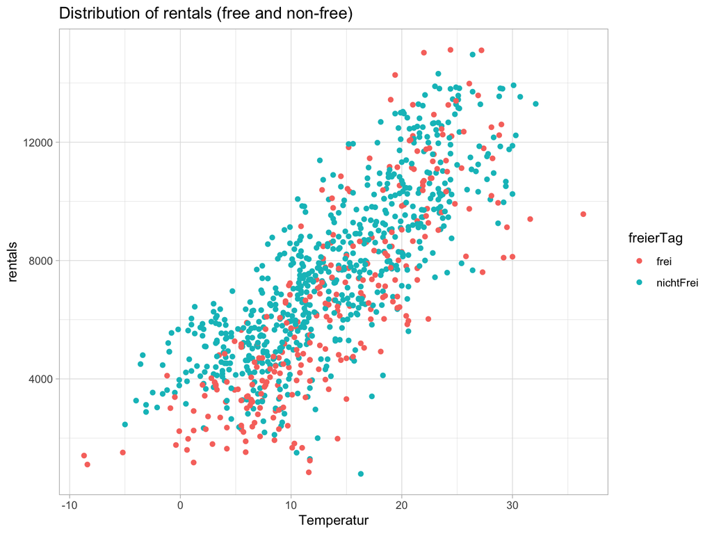

```r
train_data %>%
  ggplot(aes(x = Temperatur, y = rentals, color = freierTag)) +
  ggtitle(label = "Distribution of rentals (free and non-free)") +
  geom_point() +
  theme_light()
```

The mean temperatures of free and non-free days are (as expected) almost equal. The histograms of the temperature distribution of the rentals don´t show any differences at first glance as well.

```r
train_data %>%
  group_by(freierTag) %>%
  dplyr::summarise(Temperatur = mean(Temperatur))
```

| freierTag | Temperatur |
| --- | --- |
| frei | 13.71802 |
| nichtFrei | 13.61869 |

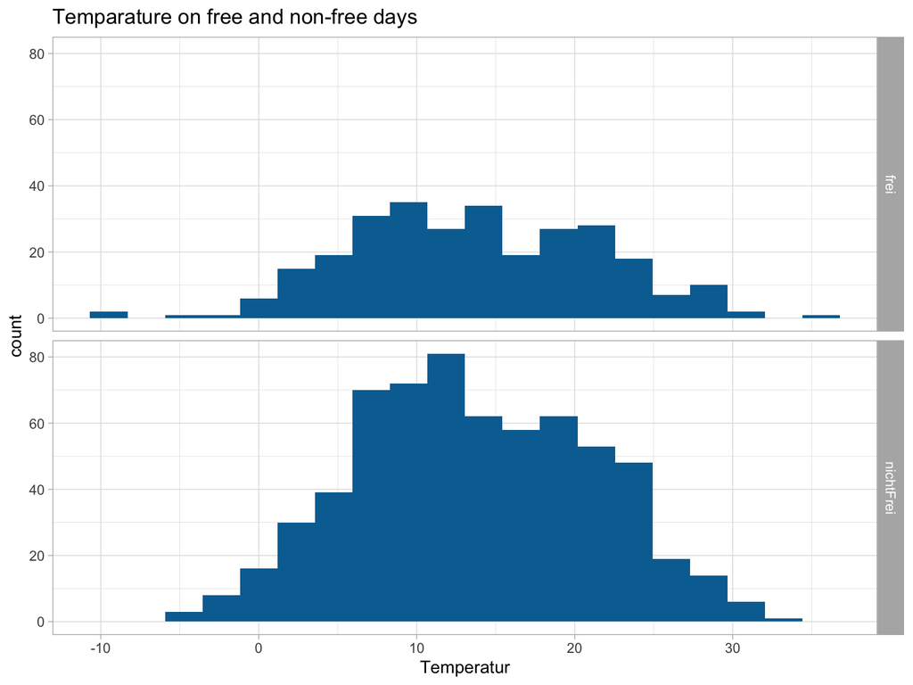

```r
train_data %>%
  ggplot(aes(x = Temperatur)) +
  geom_histogram(fill = "#006EA1", bins = 20) +
  ggtitle(label = "Temparature on free and non-free days") +
  theme_light() +
  facet_grid(facets = train_data$freierTag)
```

While there are less rentals on free days, the duration per rent is higher (duration outliers are removed from the plot).

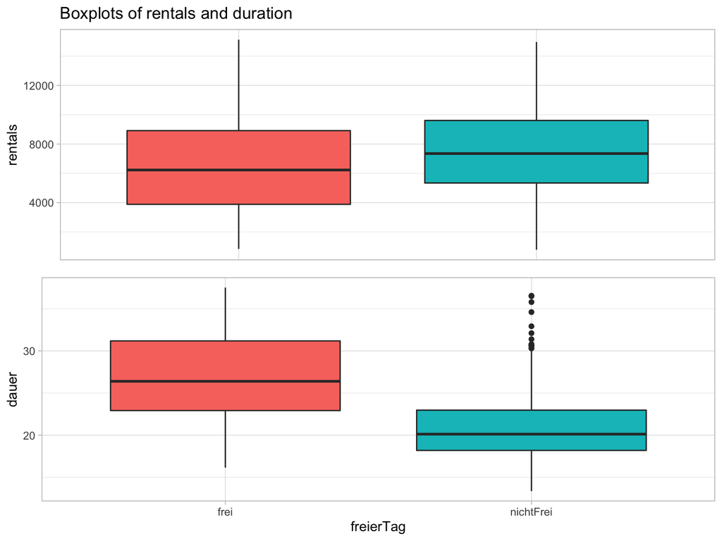

```r
# plot of rentals
plot_rentals <- train_data %>%
  ggplot(aes(x = freierTag, y = rentals, fill = freierTag)) +
  geom_boxplot(show.legend = FALSE) +
  theme_light() +
  theme(axis.title.x=element_blank(),
        axis.text.x=element_blank(),
        axis.ticks.x=element_blank()) +
  labs(labels = FALSE, title = "Boxplots of rentals and duration")

#remove outliers and save results in own object for our plot
remove_outliers <- function(x, na.rm = TRUE, ...) {
  qnt <- quantile(x, probs=c(.25, .75), na.rm = na.rm, ...)
  H <- 1.5 * IQR(x, na.rm = na.rm)
  y <- x
  y[x < (qnt[1] - H)] <- NA
  y[x > (qnt[2] + H)] <- NA
  y
}

outlier_data <- train_data
outlier_data$dauer <- remove_outliers(outlier_data$dauer, na.rm=TRUE)

# plot of the duration
plot_duration <- outlier_data %>%
  ggplot(aes(x = freierTag, y = dauer, fill = freierTag)) +
  geom_boxplot(show.legend = FALSE) +
  theme_light()

# Both plots in one graphic
ggarrange(plot_rentals, plot_duration, nrow = 2)
```

# 6 Modeling

In this chapter, we will build and train three models using the parsnip package: Logistic Regression with the glm engine, a Random Forest Model using the Ranger engine and a boosted tree model using XGBoost. As the setup for all models is the same, we will explain the individual steps only for the Logistic Regression.

## 6.1 K-fold cross-validation

Due to the amount of observations we prepare a 5-fold cross-validation

```r
set.seed(123)

cv_folds <- vfold_cv(train_data, v=5, strata = freierTag)
```

## 6.2 Logistic Regression

### 6.2.1 Set Engine

Specification which package/system will be used for the model. In this case we train a logistic regression model using the glm engine.

```r
lr_mod <-
  logistic_reg() %>%
  set_engine("glm")
```

### 6.2.2 Fit Model

We create a workflow in which we add our model as well as our recipe “class_rec”.

```r
bike_wflow_lr_mod <-
  workflow() %>%
  add_model(lr_mod) %>%
  add_recipe(class_rec)

bike_wflow_lr_mod
```

```
## ══ Workflow ═══════════════════════════════════════════════════════════════════════════════════════════════════════════════════
## Preprocessor: Recipe
## Model: logistic_reg()
##
## ── Preprocessor ───────────────────────────────────────────────────────────────────────────────────────────────────────────────
## 4 Recipe Steps
##
## ● step_rm()
## ● step_dummy()
## ● step_zv()
## ● step_corr()
##
## ── Model ──────────────────────────────────────────────────────────────────────────────────────────────────────────────────────
## Logistic Regression Model Specification (classification)
##
## Computational engine: glm
```

### 6.2.3 Train Model

In this step we train our model with our training data. We use the k-fold cross-validation and have divided our data into 5 folds. We save the predictions so we can create our metrics later on.

```r
bike_fit_lr_mode <-
  bike_wflow_lr_mod %>%
  fit_resamples(cv_folds, control = control_resamples(save_pred = TRUE))

bike_fit_lr_mode
```

| splits | id | .metrics | .notes | .predictions |
| --- | --- | --- | --- | --- |
|  | Fold1 |  |  |  |
|  | Fold2 |  |  |  |
|  | Fold3 |  |  |  |
|  | Fold4 |  |  |  |
|  | Fold5 |  |  |  |

### 6.2.4 Show and save results

To evaluate our trained model we read out the values for “Precision”, “Recall”, “Accuracy”, “ROC” and “F1” and have a look at the confusion matrix. For a better overview we create a table in which we enter the results.

```r
# Predictions
predictions_lr <- collect_predictions(bike_fit_lr_mode, summarize = TRUE)
predictions_lr
```

| .row | freierTag | .pred_frei | .pred_nichtFrei | .pred_class |
| --- | --- | --- | --- | --- |
| 1 | frei | 0.889281991 | 1.107180e-01 | frei |
| 2 | nichtFrei | 0.144514168 | 8.554858e-01 | nichtFrei |
| 3 | nichtFrei | 0.056344019 | 9.436560e-01 | nichtFrei |
| 4 | frei | 0.981189773 | 1.881023e-02 | frei |
| 5 | frei | 0.920336792 | 7.966321e-02 | frei |
| 6 | nichtFrei | 0.159323046 | 8.406770e-01 | nichtFrei |
| 7 | nichtFrei | 0.189524384 | 8.104756e-01 | nichtFrei |
| 8 | nichtFrei | 0.151086743 | 8.489133e-01 | nichtFrei |
| 9 | nichtFrei | 0.852973095 | 1.470269e-01 | frei |
| 10 | frei | 0.234133099 | 7.658669e-01 | nichtFrei |

[output cut: 915 more lines]

```r
# Confusion Matrix for folds
conf_mat_lr <- conf_mat_resampled(bike_fit_lr_mode)
conf_mat_lr
```

| Prediction | Truth | Freq |
| --- | --- | --- |
| frei | frei | 34.0 |
| frei | nichtFrei | 15.6 |
| nichtFrei | frei | 22.6 |
| nichtFrei | nichtFrei | 112.8 |

```r
# Metrics
collect_metrics(bike_fit_lr_mode, summarize = FALSE)
```

| id | .metric | .estimator | .estimate |
| --- | --- | --- | --- |
| Fold1 | accuracy | binary | 0.8118280 |
| Fold1 | roc_auc | binary | 0.8290494 |
| Fold2 | accuracy | binary | 0.7580645 |
| Fold2 | roc_auc | binary | 0.8416973 |
| Fold3 | accuracy | binary | 0.7297297 |
| Fold3 | roc_auc | binary | 0.7776864 |
| Fold4 | accuracy | binary | 0.8913043 |
| Fold4 | roc_auc | binary | 0.9508929 |
| Fold5 | accuracy | binary | 0.7771739 |
| Fold5 | roc_auc | binary | 0.8370536 |

```r
metrics_lr <- collect_metrics(bike_fit_lr_mode, summarize = TRUE)
metrics_lr
```

| .metric | .estimator | mean | n | std_err |
| --- | --- | --- | --- | --- |
| accuracy | binary | 0.7936201 | 5 | 0.02783019 |
| roc_auc | binary | 0.8472759 | 5 | 0.02832578 |

```r
# Precision, Recall and F1
precision_lr <- precision(predictions_lr, truth = predictions_lr$freierTag, estimate = predictions_lr$.pred_class)
precision_lr
```

| .metric | .estimator | .estimate |
| --- | --- | --- |
| precision | binary | 0.6854839 |

```r
recall_lr <- recall(predictions_lr, truth = predictions_lr$freierTag, estimate = predictions_lr$.pred_class)
recall_lr
```

| .metric | .estimator | .estimate |
| --- | --- | --- |
| recall | binary | 0.6007067 |

```r
fmeas_lr <- func_f_meas(precision_lr$.estimate, recall_lr$.estimate)
fmeas_lr
```

```
## [1] 0.6403013
```

```r
# Save in result tibble
Ergebnisse_class <- tibble(Model = "Logistische Regression",
                           roc_auc = metrics_lr$mean[2],
                           accuracy = metrics_lr$mean[1],
                           recall = recall_lr$.estimate,
                           precision = precision_lr$.estimate,
                           fmeas = fmeas_lr
                           )
```

Our precision in this model is 0.685, which means that 68.5% of the predictions marked as “free” are actually days off. Recall is 0.601, which means that our model has correctly identified 60.1% of all days off. The accuracy (0.794 -> 79.4%) is much higher, this could be due to the high amount of “true negative” predictions which of course have a positive influence on the accuracy.

### 6.2.5 ROC graph

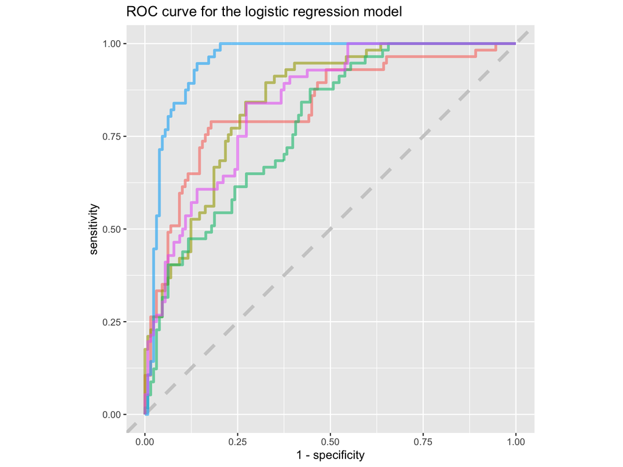

```r
bike_fit_lr_mode %>%
  collect_predictions() %>%
  group_by(id) %>%
  roc_curve(freierTag, .pred_frei) %>%
  ggplot(aes(1 - specificity, sensitivity, color = id)) +
  geom_abline(lty = 2, color = "gray80", size = 1.5) +
  ggtitle(label = "ROC curve for the logistic regression model") +
  geom_path(show.legend = FALSE, alpha = 0.6, size = 1.2) +
  coord_equal()
```

The ROC and Accuracy values of the individual folds fluctuate visibly, as can be seen in the plot. The ROC values are between 0.778 and 0.951 with a mean ROC of 0.847, the Accuracy values are between 0.730 and 0.891 with a mean of 0.794. Considering that in the training data set we have only 925 observations distributed over 5 folds, the individual fold composition can indeed be very different. Another reason could be that our model is not very robust and reacts strongly to slight fluctuations.

## 6.3 Random Forest

### 6.3.1 Set engine

```r
rf_mod <-
  rand_forest() %>%
  set_engine("ranger") %>%
  set_mode("classification")
```

### 6.3.2 Fit Model

```r
bike_wflow_rf_mod <-
  workflow() %>%
  add_model(rf_mod) %>%
  add_recipe(class_rec)

bike_wflow_rf_mod
```

```
## ══ Workflow ═══════════════════════════════════════════════════════════════════════════════════════════════════════════════════
## Preprocessor: Recipe
## Model: rand_forest()
##
## ── Preprocessor ───────────────────────────────────────────────────────────────────────────────────────────────────────────────
## 4 Recipe Steps
##
## ● step_rm()
## ● step_dummy()
## ● step_zv()
## ● step_corr()
##
## ── Model ──────────────────────────────────────────────────────────────────────────────────────────────────────────────────────
## Random Forest Model Specification (classification)
##
## Computational engine: ranger
```

### 6.3.3 Train Model

```r
bike_fit_rf_mode <-
  bike_wflow_rf_mod %>%
  fit_resamples(cv_folds, control = control_resamples(save_pred = TRUE))

bike_fit_rf_mode
```

| splits | id | .metrics | .notes | .predictions |
| --- | --- | --- | --- | --- |
|  | Fold1 |  |  |  |
|  | Fold2 |  |  |  |
|  | Fold3 |  |  |  |
|  | Fold4 |  |  |  |
|  | Fold5 |  |  |  |

### 6.3.4 Save and show results

```r
# Predictions
predictions_rf <- collect_predictions(bike_fit_rf_mode, summarize = TRUE)
predictions_rf
```

| .row | freierTag | .pred_frei | .pred_nichtFrei | .pred_class |
| --- | --- | --- | --- | --- |
| 1 | frei | 0.678313034 | 0.32168697 | frei |
| 2 | nichtFrei | 0.409215079 | 0.59078492 | nichtFrei |
| 3 | nichtFrei | 0.367506349 | 0.63249365 | nichtFrei |
| 4 | frei | 0.818995482 | 0.18100452 | frei |
| 5 | frei | 0.812197249 | 0.18780275 | frei |
| 6 | nichtFrei | 0.149729673 | 0.85027033 | nichtFrei |
| 7 | nichtFrei | 0.135891941 | 0.86410806 | nichtFrei |
| 8 | nichtFrei | 0.177504274 | 0.82249573 | nichtFrei |
| 9 | nichtFrei | 0.789973668 | 0.21002633 | frei |
| 10 | frei | 0.444488095 | 0.55551190 | nichtFrei |

[output cut: 915 more lines]

```r
# Confusion Matrix for folds
conf_mat_rf <- conf_mat_resampled(bike_fit_rf_mode)
conf_mat_rf
```

| Prediction | Truth | Freq |
| --- | --- | --- |
| frei | frei | 45.8 |
| frei | nichtFrei | 10.4 |
| nichtFrei | frei | 10.8 |
| nichtFrei | nichtFrei | 118.0 |

```r
# Metrics
collect_metrics(bike_fit_rf_mode, summarize = FALSE)
```

| id | .metric | .estimator | .estimate |
| --- | --- | --- | --- |
| Fold1 | accuracy | binary | 0.9193548 |
| Fold1 | roc_auc | binary | 0.9687203 |
| Fold2 | accuracy | binary | 0.8763441 |
| Fold2 | roc_auc | binary | 0.9442404 |
| Fold3 | accuracy | binary | 0.8648649 |
| Fold3 | roc_auc | binary | 0.9152961 |
| Fold4 | accuracy | binary | 0.9130435 |
| Fold4 | roc_auc | binary | 0.9524275 |
| Fold5 | accuracy | binary | 0.8532609 |
| Fold5 | roc_auc | binary | 0.8974609 |

```r
metrics_rf <- collect_metrics(bike_fit_rf_mode, summarize = TRUE)
metrics_rf
```

| .metric | .estimator | mean | n | std_err |
| --- | --- | --- | --- | --- |
| accuracy | binary | 0.8853736 | 5 | 0.01314099 |
| roc_auc | binary | 0.9356290 | 5 | 0.01288721 |

```r
# Precision, Recall and F1
precision_rf <- precision(predictions_rf, truth = predictions_rf$freierTag, estimate = predictions_rf$.pred_class)
precision_rf
```

| .metric | .estimator | .estimate |
| --- | --- | --- |
| precision | binary | 0.8149466 |

```r
recall_rf <- recall(predictions_rf, truth = predictions_rf$freierTag, estimate = predictions_rf$.pred_class)
recall_rf
```

| .metric | .estimator | .estimate |
| --- | --- | --- |
| recall | binary | 0.8091873 |

```r
fmeas_rf <- func_f_meas(precision_rf$.estimate, recall_rf$.estimate)
fmeas_rf
```

```
## [1] 0.8120567
```

```r
# Add to result tibble
Ergebnisse_class <- Ergebnisse_class %>%
                           add_row(Model = "Random Forest",
                           roc_auc = metrics_rf$mean[2],
                           accuracy = metrics_rf$mean[1],
                           recall = recall_rf$.estimate,
                           precision = precision_rf$.estimate,
                           fmeas = fmeas_rf
                           )
```

Our precision in this model is 0.815, which means that 81.5% of the predictions marked as “free” are actually days off. Recall is 0.809, which means that our model has correctly identified 80.9% of all days off. These results are way better than in the Logistic Regression. The accuracy was already very good in the Logistic Regression (79.4%) and is even better in the Random Forest Model with 88.5%.

### 6.3.5 ROC graph

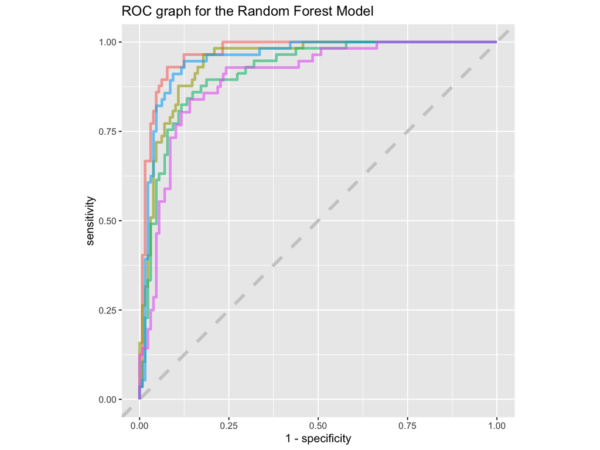

```r
bike_fit_rf_mode %>%
  collect_predictions() %>%
  group_by(id) %>%
  roc_curve(freierTag, .pred_frei) %>%
  ggplot(aes(1 - specificity, sensitivity, color = id)) +
  geom_abline(lty = 2, color = "gray80", size = 1.5) +
  geom_path(show.legend = FALSE, alpha = 0.6, size = 1.2) +
  ggtitle(label = "ROC graph for the Random Forest Model") +
  coord_equal()
```

Compared to our first model, the fluctuations of the Random Forest Model are visibly lower. Therefore, the individual folds seem to have a much smaller influence on the model performance. At first glance, the model seems more robust than the logistic regression model. The values for ROC are between 0.897 and 0.969 with a mean of 0.936, for accuracy between 0.853 and 0.919 with a mean of 0.885.

## 6.4 Boosted tree (XGBoost)

###Set engine

```r
xgb_mod <-
  boost_tree() %>%
  set_engine("xgboost") %>%
  set_mode("classification")
```

### 6.4.1 Fit Model

```r
bike_wflow_xgb_mod <-
  workflow() %>%
  add_model(xgb_mod) %>%
  add_recipe(class_rec)

bike_wflow_xgb_mod
```

```
## ══ Workflow ═══════════════════════════════════════════════════════════════════════════════════════════════════════════════════
## Preprocessor: Recipe
## Model: boost_tree()
##
## ── Preprocessor ───────────────────────────────────────────────────────────────────────────────────────────────────────────────
## 4 Recipe Steps
##
## ● step_rm()
## ● step_dummy()
## ● step_zv()
## ● step_corr()
##
## ── Model ──────────────────────────────────────────────────────────────────────────────────────────────────────────────────────
## Boosted Tree Model Specification (classification)
##
## Computational engine: xgboost
```

### 6.4.2 Train Model

```r
bike_fit_xgb_mode <-
  bike_wflow_xgb_mod %>%
  fit_resamples(cv_folds, control = control_resamples(save_pred = TRUE))

bike_fit_xgb_mode
```

| splits | id | .metrics | .notes | .predictions |
| --- | --- | --- | --- | --- |
|  | Fold1 |  |  |  |
|  | Fold2 |  |  |  |
|  | Fold3 |  |  |  |
|  | Fold4 |  |  |  |
|  | Fold5 |  |  |  |

### 6.4.3 Show and save results

```r
# Predictions
predictions_xgb <- collect_predictions(bike_fit_xgb_mode)
predictions_xgb
```

| id | .pred_frei | .pred_nichtFrei | .row | .pred_class | freierTag |
| --- | --- | --- | --- | --- | --- |
| Fold1 | 0.019762814 | 0.98023719 | 6 | nichtFrei | nichtFrei |
| Fold1 | 0.040969193 | 0.95903081 | 18 | nichtFrei | nichtFrei |
| Fold1 | 0.884965748 | 0.11503425 | 21 | frei | nichtFrei |
| Fold1 | 0.041880548 | 0.95811945 | 33 | nichtFrei | frei |
| Fold1 | 0.816051468 | 0.18394853 | 38 | frei | frei |
| Fold1 | 0.327567339 | 0.67243266 | 40 | nichtFrei | nichtFrei |
| Fold1 | 0.022578120 | 0.97742188 | 53 | nichtFrei | nichtFrei |
| Fold1 | 0.428436637 | 0.57156336 | 54 | nichtFrei | frei |
| Fold1 | 0.019757688 | 0.98024231 | 56 | nichtFrei | nichtFrei |
| Fold1 | 0.016049981 | 0.98395002 | 58 | nichtFrei | nichtFrei |

[output cut: 915 more lines]

```r
# Confusion Matrix for folds
conf_mat_xgb <- conf_mat_resampled(bike_fit_xgb_mode)
conf_mat_xgb
```

| Prediction | Truth | Freq |
| --- | --- | --- |
| frei | frei | 47.6 |
| frei | nichtFrei | 11.0 |
| nichtFrei | frei | 9.0 |
| nichtFrei | nichtFrei | 117.4 |

```r
# Metrics
collect_metrics(bike_fit_xgb_mode, summarize = FALSE)
```

| id | .metric | .estimator | .estimate |
| --- | --- | --- | --- |
| Fold1 | accuracy | binary | 0.9086022 |
| Fold1 | roc_auc | binary | 0.9529444 |
| Fold2 | accuracy | binary | 0.9086022 |
| Fold2 | roc_auc | binary | 0.9533524 |
| Fold3 | accuracy | binary | 0.8756757 |
| Fold3 | roc_auc | binary | 0.9240680 |
| Fold4 | accuracy | binary | 0.9076087 |
| Fold4 | roc_auc | binary | 0.9443359 |
| Fold5 | accuracy | binary | 0.8586957 |
| Fold5 | roc_auc | binary | 0.9133650 |

```r
metrics_xgb <- collect_metrics(bike_fit_xgb_mode, summarize = TRUE)
metrics_xgb
```

| .metric | .estimator | mean | n | std_err |
| --- | --- | --- | --- | --- |
| accuracy | binary | 0.8918369 | 5 | 0.010417352 |
| roc_auc | binary | 0.9376131 | 5 | 0.008060434 |

```r
# Precision, Recall and F1
precision_xgb <- precision(predictions_xgb, truth = predictions_xgb$freierTag, estimate = predictions_xgb$.pred_class)
precision_xgb
```

| .metric | .estimator | .estimate |
| --- | --- | --- |
| precision | binary | 0.8122867 |

```r
recall_xgb <- recall(predictions_xgb, truth = predictions_xgb$freierTag, estimate = predictions_xgb$.pred_class)
recall_xgb
```

| .metric | .estimator | .estimate |
| --- | --- | --- |
| recall | binary | 0.8409894 |

```r
fmeas_xgb <- func_f_meas(precision_xgb$.estimate, recall_xgb$.estimate)
fmeas_xgb
```

```
## [1] 0.8263889
```

```r
# Add to result tibble
Ergebnisse_class <- Ergebnisse_class %>%
                           add_row(Model = "XGBoost",
                           roc_auc = metrics_xgb$mean[2],
                           accuracy = metrics_xgb$mean[1],
                           recall = recall_xgb$.estimate,
                           precision = precision_xgb$.estimate,
                           fmeas = fmeas_xgb
                           )
```

Our precision in this model is 0.812, which means that 81.2% of the predictions marked as “free” are actually days off. Recall is 0.841, which means that our model has correctly identified 84.1% of all days off. While the precision is slightly worse than in the Random Forest Model, the Recall is higher by a good amount. The accuracy is with 89.2% on the same level as for the Random Forest Model (88.5%).

### 6.4.4 ROC

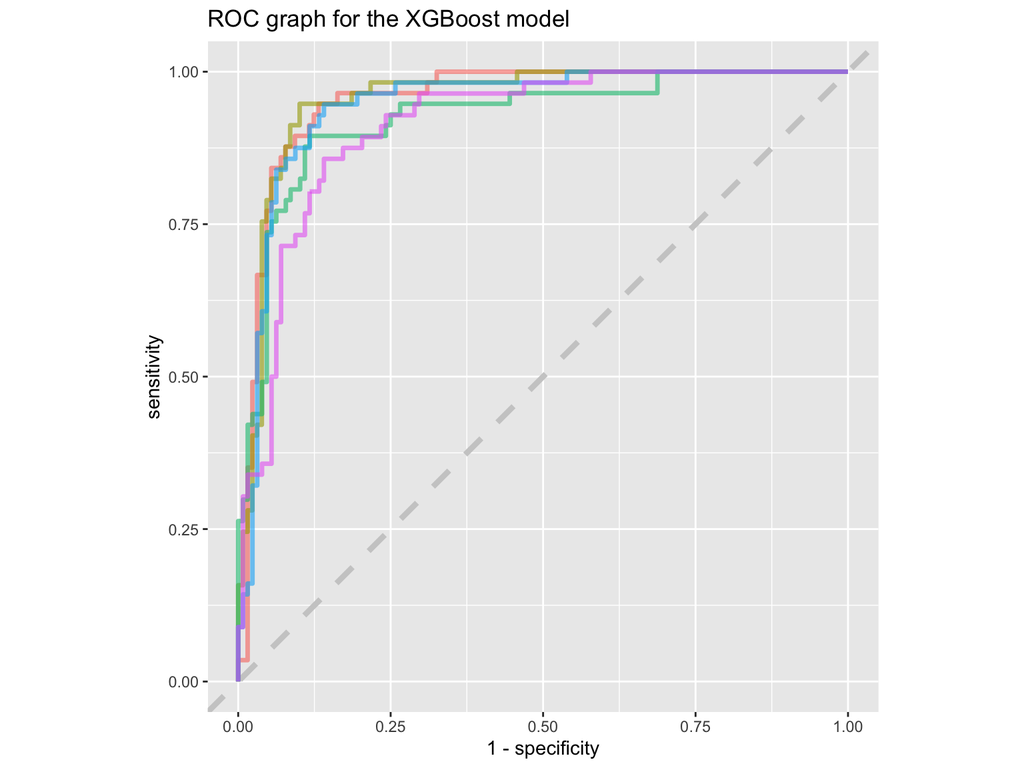

```r
bike_fit_xgb_mode %>%
  collect_predictions() %>%
  group_by(id) %>%
  roc_curve(freierTag, .pred_frei) %>%
  ggplot(aes(1 - specificity, sensitivity, color = id)) +
  geom_abline(lty = 2, color = "gray80", size = 1.5) +
  geom_path(show.legend = FALSE, alpha = 0.6, size = 1.2) +
  ggtitle(label = "ROC graph for the XGBoost model") +
  coord_equal()
```

In this model, the fluctuations are again significantly lower with a range of 0.913 - 0.953 (mean: 0.938) for ROC and 0.859 - 0.909 (mean: 0.892) for accuracy, making the model even more robust than the random forest model.

# 7 Evaluation and final model

## 7.1 Results & selecting final models

As our results show, the performance of the “XGBoost” model is best on the training data across almost all parameters. If the business case requires higher “precision”, the Random Forest Model could also be considered as the final model. In our model development we refrained from tuning with “Threshold”, when adjusting this value the model selection could change again, as this of course has direct influence on the parameters (higher Threshold means higher Precision and lower Recall).

The accuracy is very similar over all models. These small differences show very well why accuracy is generally not a good indication of the quality of the model. The “disadvantage” of this parameter is that this value benefits from the many True Negative predictions. Of course, this is not bad per se, but it reduces the informative value of the accuracy. More meaningful is therefore the consideration of Recall and Precision.

In the Business Understanding we have chosen “F1” as the selection parameter. So we will choose XGBoost and train and evaluate the test data with it.

```r
Ergebnisse_class
```

| Model | roc_auc | accuracy | recall | precision | fmeas |
| --- | --- | --- | --- | --- | --- |
| Logistische Regression | 0.8472759 | 0.7936201 | 0.6007067 | 0.6854839 | 0.6403013 |
| Random Forest | 0.9356290 | 0.8853736 | 0.8091873 | 0.8149466 | 0.8120567 |
| XGBoost | 0.9376131 | 0.8918369 | 0.8409894 | 0.8122867 | 0.8263889 |

## 7.2 Fit with test data

```r
final_model <- bike_wflow_xgb_mod %>%
  last_fit(split_data)
```

## 7.3 ROC, Accuracy, Recall, Precision, F1

```r
# Collect Metrics and Predictions
metrics_final <- collect_metrics(final_model)

conf_mat_final <- collect_predictions(final_model) %>%
  conf_mat(freierTag, .pred_class)

# Berechnung von Recall, Precision und F1
recall_final <- func_recall(conf_mat_final$table[1, 1], conf_mat_final$table[1, 2])
precision_final <- func_precision(conf_mat_final$table[1, 1], conf_mat_final$table[2, 1])
fmeas_final <- func_f_meas(precision_final, recall_final)

# Speichern in einer Ergebnistabelle
Ergebnisse_final <- tibble(Model = "Final XGBoost",
                          roc_auc = metrics_final$.estimate[2],
                          accuracy = metrics_final$.estimate[1],
                          recall = recall_final,
                          precision = precision_final,
                          fmeas = fmeas_final
                          )

Ergebnisse_final
```

| Model | roc_auc | accuracy | recall | precision | fmeas |
| --- | --- | --- | --- | --- | --- |
| Final XGBoost | 0.9549995 | 0.9055375 | 0.8282828 | 0.8723404 | 0.8497409 |

As the results show, the performance of our XGBoost model on the test data is even better than on the training data in some parameters. But basically the results are very similar and therefore we can assume that the model is robust and reliable.

### 7.3.1 ROC graph

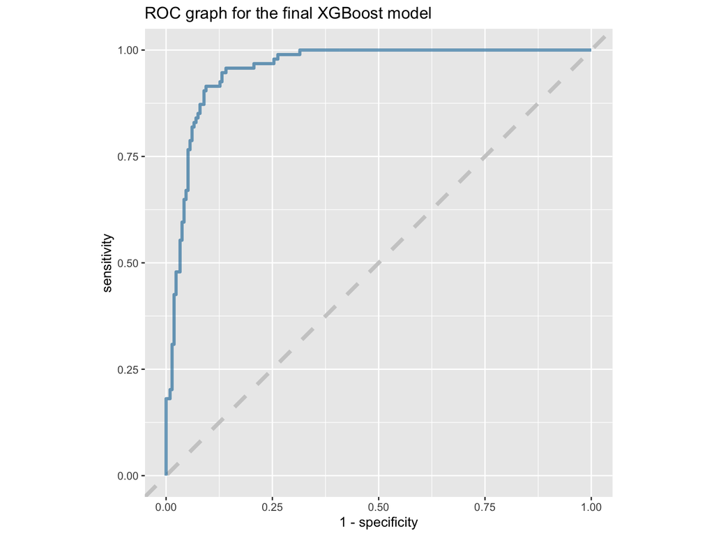

```r
final_model %>%
  collect_predictions() %>%
  roc_curve(freierTag, .pred_frei) %>%
  ggplot(aes(1 - specificity, sensitivity)) +
  geom_abline(lty = 2, color = "gray80", size = 1.5) +
  geom_path(show.legend = FALSE, alpha = 0.6, size = 1.2, color = "#006EA1") +
  ggtitle(label = "ROC graph for the final XGBoost model") +
  coord_equal()
```

The area under the ROC curve (AUC) can be used as a summary of the model skill. In our final model, the value roc_auc is 0.955 which means that there is a chance of 95.5% that the model is able to distinguish between a free and a non-free day.

### 7.3.2 PR curve

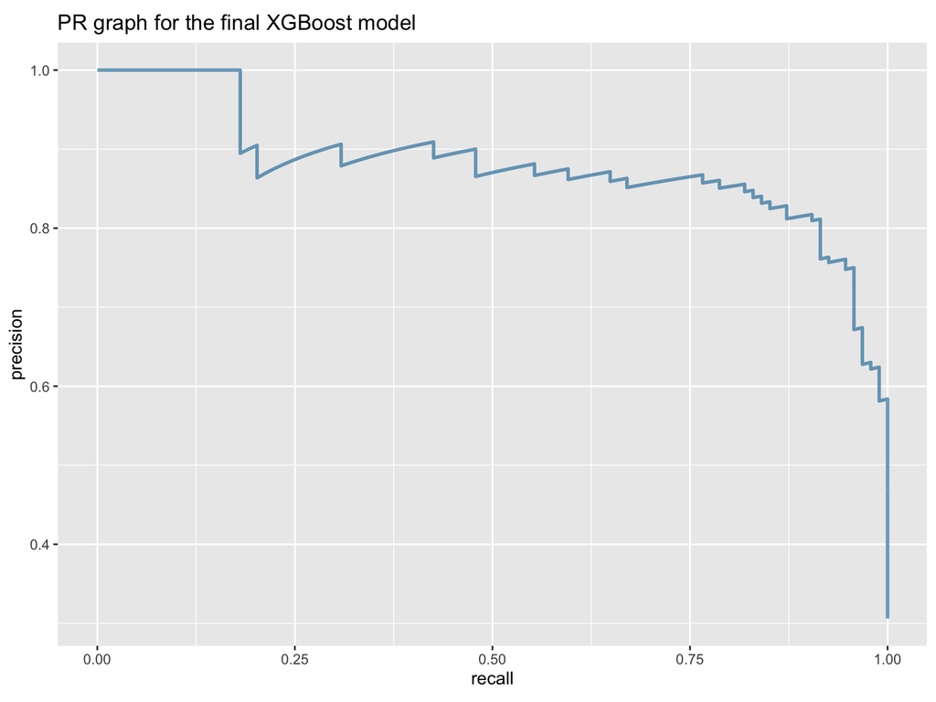

```r
final_model %>%
  collect_predictions() %>%
  pr_curve(freierTag, .pred_frei) %>%
  ggplot(aes(x = recall, y = precision)) +
  geom_path(show.legend = FALSE, alpha = 0.6, size = 1, color = "#006EA1") +
  ggtitle(label = "PR graph for the final XGBoost model") +
  coord_equal()
```

The PR curve is a good tool for classification problems which have an imbalance in the observations for each class. Our PR curve doesn´t indicate such a problem for our test data.

## 7.4 Summary

As the results show, the performance of our XGBoost model on the test data is even better than on the training data in some parameters. But basically the results are very similar and therefore in our test it can be assumed that the model is robust and reliable.

As in our regression test it must be mentioned here as well that some of the predictors of our models are very difficult to predict itself. The prediction of weather data is generally very error-prone. Therefore, our model in the real world may be even less accurate than in our experiment with the test data.

```r
Ergebnisse_final <- Ergebnisse_final %>%
                           add_row(Model = "Training XGBoost",
                           roc_auc = metrics_xgb$mean[2],
                           accuracy = metrics_xgb$mean[1],
                           recall = recall_xgb$.estimate,
                           precision = precision_xgb$.estimate,
                           fmeas = fmeas_xgb
                           )
Ergebnisse_final
```

| Model | roc_auc | accuracy | recall | precision | fmeas |
| --- | --- | --- | --- | --- | --- |
| Final XGBoost | 0.9549995 | 0.9055375 | 0.8282828 | 0.8723404 | 0.8497409 |
| Training XGBoost | 0.9376131 | 0.8918369 | 0.8409894 | 0.8122867 | 0.8263889 |

# 8 Deployment

The deployment on the whole dataset and the prediction of future values is not part of this project.